# Lab08_Homework_more-dplyr_ref

曾子軒 Teaching Assiatant

2021/04/13

## 作業目的: more dplyr

這份作業希望能夠讓你熟悉於利用 dprly 當中 `select()` 相關的 helper function 與 `across()`。

這次的作業使用美國 Cencus Bureau 提供的[普查資料](https://data.census.gov/)，主要挑選人口變數與社經地位變數，並額外利用 2016 和 2020 總統大選[選舉結果](https://github.com/tonmcg/US_County_Level_Election_Results_08-20/)，練習不同資料表之間的串接，並查看可能影響選舉結果的變數。

## 作業: more dplyr

```r
### 這邊不要動
library(tidyverse)

##### import data
df_demo <- read_csv("data/Lab08/DEMOGRAPHIC AND HOUSING ESTIMATES.csv")
df_demo %>% head(1)

df_social <- read_csv("data/Lab08/SOCIAL CHARACTERISTICS.csv")
df_social %>% head(1)

df_vote_agg_2020 <- read_csv("data/Lab08/df_vote_agg_2020.csv")
df_vote_agg_2020 %>% head(1)
```

[output not shown]

[output cut: 10 more lines]

[output not shown]

### 1. 幫我抓性別

從 `df_demo` 抓出男性人數、女性人數、男性佔比、女性佔比。

```r
### your code
df_gender <- df_demo %>% select(matches("E")) %>% select(-matches("PE")) %>% select(GEO_ID:DP05_0004E)
df_gender <- df_gender %>% `colnames<-`(df_gender %>% head(1) %>% unlist() %>% unname() %>% str_to_lower() %>% str_remove_all("estimate!!") %>%
                             str_replace_all(" ", "-") %>% str_replace_all("!!", "_")) %>%
  rename(pop = 3, pop_m = 4, pop_f= 5) %>% select(-6) %>%
  filter(`geographic-area-name` !="Puerto Rico") %>%
  slice(-1) %>% mutate(across(-matches("id|geographic"), ~as.numeric(.))) %>%
  mutate(per_m = pop_m/pop, per_f = pop_f/pop)
df_gender %>% head(1)
```

```
#> # A tibble: 1 x 7
#>   id          `geographic-area-name`     pop   pop_m   pop_f per_m per_f
#>   <chr>       <chr>                    <dbl>   <dbl>   <dbl> <dbl> <dbl>
#> 1 0400000US01 Alabama                4876250 2359355 2516895 0.484 0.516
```

### 2. 幫我抓投票人口

從 `df_demo` 抓出投票人口、投票女性人口、投票男性人口、投票女性佔比、投票男性佔比。

```r
### your code
df_vote <- df_demo %>% select(matches("E")) %>% select(-matches("PE")) %>% select(-(DP05_0001E:DP05_0085E))
df_vote <- df_vote %>% `colnames<-`(df_vote %>% head(1) %>% unlist() %>% unname() %>% str_to_lower() %>% str_remove_all("estimate!!") %>%
                                      str_replace_all(" ", "-") %>% str_replace_all("!!", "_")) %>%
  rename(unit_housing = 3, vote_all = 4, vote_m = 5, vote_f = 6) %>%
  filter(`geographic-area-name` !="Puerto Rico") %>%
  slice(-1) %>% mutate(across(-matches("id|geographic"), ~as.numeric(.))) %>%
  mutate(per_vote_m = vote_m/vote_all, per_vote_f = vote_f/vote_all)
df_vote %>% head(1)
```

```
#> # A tibble: 1 x 8
#>   id        `geographic-area-na… unit_housing vote_all  vote_m vote_f per_vote_m
#>   <chr>     <chr>                       <dbl>    <dbl>   <dbl>  <dbl>      <dbl>
#> 1 0400000U… Alabama                   2255026  3685074 1749845 1.94e6      0.475
#> # … with 1 more variable: per_vote_f <dbl>
```

### 3. 幫我抓種族人口

```r
### your code
df_race <- df_demo %>% select(matches("E")) %>% select(-matches("PE")) %>% select(-(DP05_0001E:DP05_0032E)) %>% select(GEO_ID:DP05_0085E) %>% select(1:5, 7:8, 14, 22, 27)
df_race <- df_race %>% `colnames<-`(df_race %>% head(1) %>% unlist() %>% unname() %>% str_to_lower() %>% str_remove_all("estimate!!") %>%
                                    str_replace_all(" ", "-") %>% str_replace_all("!!", "_")) %>%
  rename(race_one = 4, race_two = 5, race_one_white = 6, race_one_black = 7, race_one_asian = 8,
         race_one_native_pasific = 9, race_one_other = 10) %>% select(-3) %>%
  filter(`geographic-area-name` !="Puerto Rico") %>%
  slice(-1) %>% mutate(across(-matches("id|geographic"), ~as.numeric(.))) %>%
  left_join(df_gender %>% select(1:3)) %>% mutate(across(is.numeric, ~(./pop))) %>%
  select(-pop)
df_race %>% head(1)
```

```
#> # A tibble: 1 x 9
#>   id        `geographic-area-na… race_one race_two race_one_white race_one_black
#>   <chr>     <chr>                   <dbl>    <dbl>          <dbl>          <dbl>
#> 1 0400000U… Alabama                 0.981   0.0189          0.681          0.266
#> # … with 3 more variables: race_one_asian <dbl>, race_one_native_pasific <dbl>,
#> #   race_one_other <dbl>
```

從 `df_social` 抓出教育相關變數，不用全抓，抓 25-years-and-over 人口, less-than-9th-grade, 9th-to-12th-grade,-no-diploma, high-school-graduate, some-college,-no-degree, associate’s-degree, bachelor’s-degree, graduate-or-professional-degree.

```r
### your code
df_educational_attainment <- df_social %>% select(matches("E")) %>% select(-matches("PE")) %>% select(-(DP02_0001E:DP02_0058E)) %>% select(GEO_ID:DP02_0068E)
df_educational_attainment <- df_educational_attainment %>% `colnames<-`(df_educational_attainment %>% head(1) %>% unlist() %>% unname() %>% str_to_lower() %>% str_remove_all("estimate!!") %>%
                                      str_replace_all(" ", "-") %>% str_replace_all("!!", "_")) %>%
  rename(education = 3, education_js = 4, education_high = 5, education_high_gradu = 6, education_college = 7,
         education_associate = 8, education_bachelor = 9, education_gradu_professional = 10) %>% select(-(11:12)) %>%
  filter(`geographic-area-name` !="Puerto Rico") %>%
  slice(-1) %>% mutate(across(-matches("id|geographic"), ~as.numeric(.))) %>%
  mutate(across(matches("education_"), ~(./education)))
df_educational_attainment %>% head(1)
```

```
#> # A tibble: 1 x 10
#>   id     `geographic-are… education education_js education_high education_high_…
#>   <chr>  <chr>                <dbl>        <dbl>          <dbl>            <dbl>
#> 1 04000… Alabama            3320877       0.0431         0.0951            0.308
#> # … with 4 more variables: education_college <dbl>, education_associate <dbl>,
#> #   education_bachelor <dbl>, education_gradu_professional <dbl>
```

### 5. 串起來畫圖

把所有資料表串起來後畫圖，你的變數命名可能跟我不一樣！

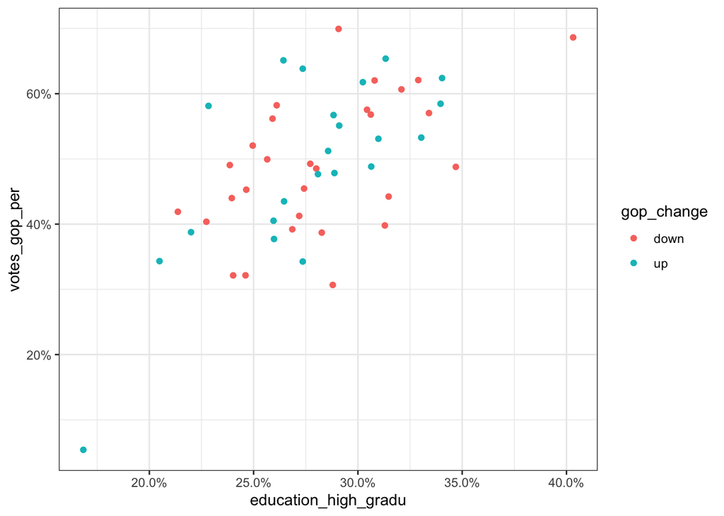

```r
### your code
df_state_metric <-
  df_gender %>%
  left_join(df_vote, by = c("id", "geographic-area-name")) %>%
  left_join(df_race, by = c("id", "geographic-area-name")) %>%
  left_join(df_educational_attainment, by = c("id", "geographic-area-name")) %>%
  rename(state=2)

df_presidential_2020 <- df_vote_agg_2020 %>% left_join(df_state_metric, by = "state") %>%
  mutate(gop_change = if_else(votes_gop_per > votes_gop_per_2016, "up", "down"),
         dem_change = if_else(votes_dem_per > votes_dem_per_2016, "up", "down"))

##### Viz
df_presidential_2020 %>%
  ggplot(aes(x = education_high_gradu, y = votes_gop_per, color = gop_change)) +
  geom_point() +
  theme_bw() +
  scale_x_continuous(labels = scales::percent) +
  scale_y_continuous(labels = scales::percent)
```

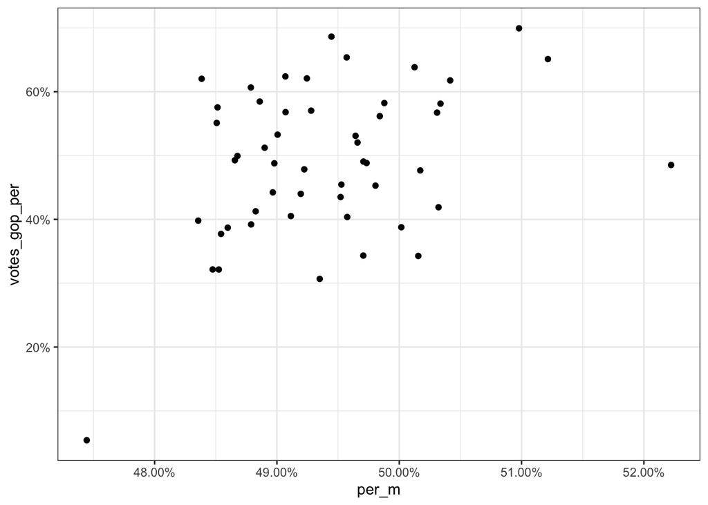

```r
df_presidential_2020 %>%
  ggplot(aes(x = per_m, y = votes_gop_per)) +
  geom_point() +
  theme_bw() +
  scale_x_continuous(labels = scales::percent) +
  scale_y_continuous(labels = scales::percent)
```

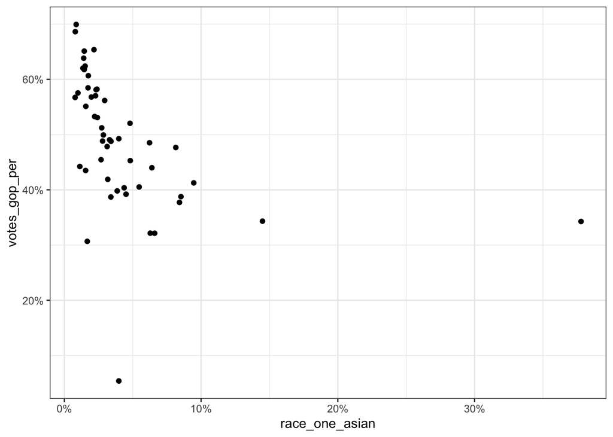

```r
df_presidential_2020 %>%
  ggplot(aes(x = race_one_asian, y = votes_gop_per)) +
  geom_point() +
  theme_bw() +
  scale_x_continuous(labels = scales::percent) +
  scale_y_continuous(labels = scales::percent)
```